# Компьютерная работа №1 Многомерные статистические методы 2020-21 гг. — 2 курс

#### **7.5. График наблюдаемых и модельных значений зависимой переменной**

Построим график модельных и фактических значений (предсказанных и истинных) зависимой переменной для наилучшей модели:

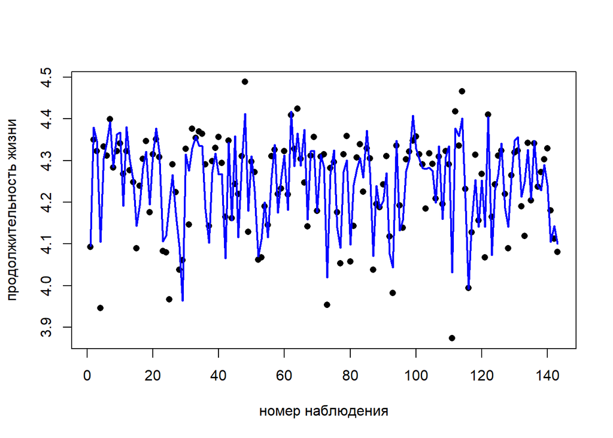

```r
pred2 <- predict(nlm2) #у с крышечкой
plot(seq(1, nrow(data2), 1), data2$l_Life_exp, pch = 16,
     xlab = 'номер наблюдения', ylab = 'продолжительность жизни')
lines(seq(1, nrow(data2), 1), pred2, col = 'blue', lwd = 2)
```

На данном графике синей линией показаны модельные значения зависимой переменной, а черные точки означают фактические значения данной переменной. Как мы видим, эти элементы графика в целом совпадают, что говорит об относительном качестве модели.

Построим еще один график, подтверждающий качество нашей модели. Во всех моделях достаточно большой вклад вносит переменная `Adult_mort`, поэтому следующий график построим для зависимости продолжительности жизни и взрослой смертности.

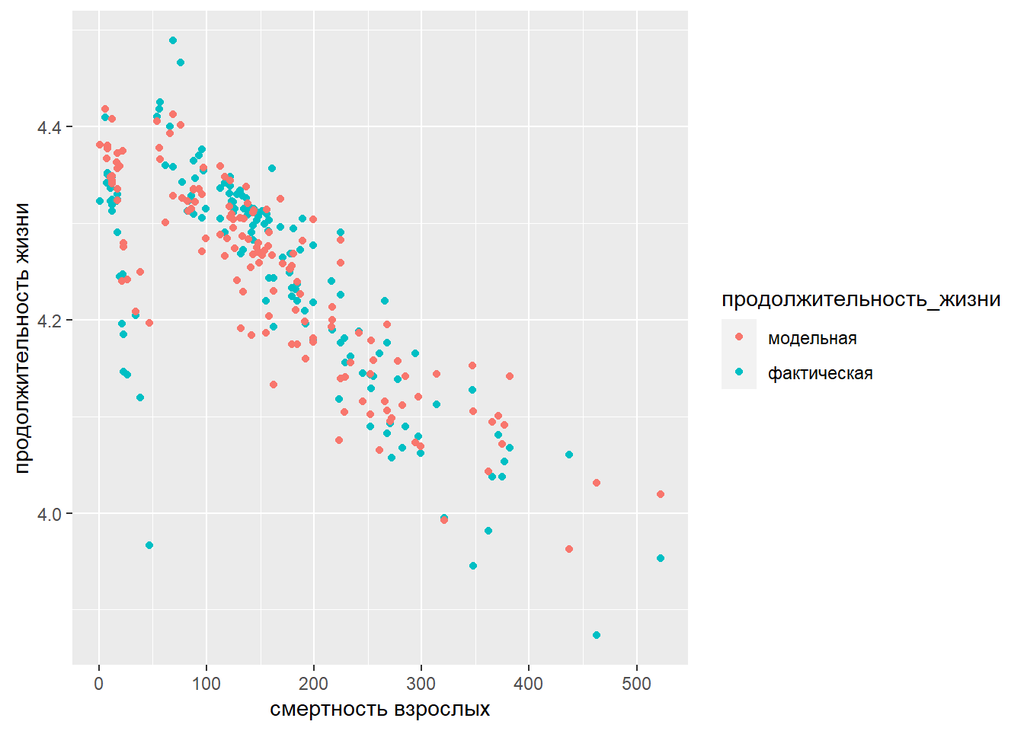

```r
df_true2 <- data.frame(x = data2$Adult_mort, y = data2$l_Life_exp)
df_true2$продолжительность_жизни <- 'фактическая'

df_pred2 <- data.frame(x = data2$Adult_mort, y = pred2)
df_pred2$продолжительность_жизни <- 'модельная'

df2 <- rbind.data.frame(df_true2, df_pred2)

ggplot(df2, aes(x = x, y = y)) +
  geom_point(aes(color = продолжительность_жизни)) +
  labs(x = 'смертность взрослых', y = 'продолжительность жизни')
```

Можно заметить, что фактическое распределение поделено на некоторые 2 кластера, и модельные значения даже повторяют это разделение на кластеры. Это безусловно хороший показатель, значит наша модель достаточно точная.